# all_failures

Attribution 4.0 International (CC BY 4.0)

https://creativecommons.org/licenses/by/4.0/

date; find . | grep csv | while read full_path; do cat $full_path | awk -F, '$5 == "1" {print $0}' >> all_failures_all_smart__column_count_varies.log; done; date count the number of columns in the file by counting commas per line while read p; do echo $p | tr -cd , | wc -c; done < all_failures_all_smart__column_count_varies.log Because the columns are inconsistent, check which columns are aligned date; find . | grep csv | while read full_path; do head -n1 $full_path >> all_column_headers.log; done; date Now we can determine which columns are consistent for i in {1..130}; do echo column $i; cat all_column_headers.log | cut -d',' -f$i | sort | uniq -c; done answer: columns 1 to 31 are present in all CSVs. Reduce failure list to first 31 columns cat all_failures_all_smart__column_count_varies.log | cut -d',' -f1-31 > all_failures_smart_columns1to31.log

Smart_9_raw is power-on hours

https://en.wikipedia.org/wiki/S.M.A.R.T.#Known_ATA_S.M.A.R.T._attributes

```python
import pandas
print('pandas',pandas.__version__)
import glob
import pickle
import numpy
import time
import matplotlib.pyplot as plt
```

```
pandas 0.23.4
```

get the headers for the dataframe from a CSV

```python
df_header_only=pandas.read_csv('zipped_data/data_Q2_2018.zip_folder/2018-04-01.csv',nrows=3)
#df_header_only.head()
```

```python
df = pandas.read_csv('data_synthesized_from_csvs/all_failures_smart_columns1to31.log',header=None)
df.columns=df_header_only.columns[0:31]
df.shape
```

```
(8743, 31)
```

# histogram of power-on hours at time of failure

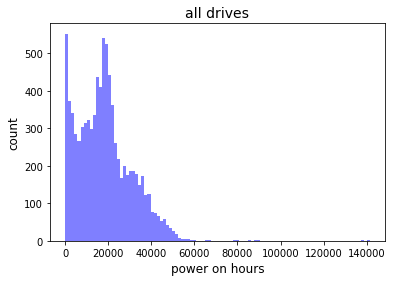

```python
n, bins, patches = plt.hist(df['smart_9_raw'].dropna(how='any'), bins=100, facecolor='blue', alpha=0.5)
plt.xlabel('power on hours',fontsize=12)
plt.ylabel('count',fontsize=12);
plt.title('all drives',fontsize=14);
```

### zoom in on relevant lifespans

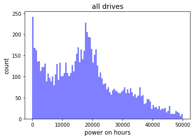

```python
n, bins, patches = plt.hist(df[df['smart_9_raw'] < 50000]['smart_9_raw'].dropna(how='any'), bins=100, facecolor='blue', alpha=0.5)
plt.xlabel('power on hours',fontsize=12)
plt.ylabel('count',fontsize=12);
plt.title('all drives',fontsize=14);
```

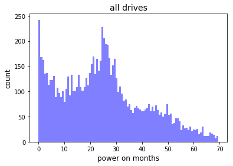

```python
n, bins, patches = plt.hist(df[df['smart_9_raw'] < 50000]['smart_9_raw'].dropna(how='any')/24/30, bins=100, facecolor='blue', alpha=0.5)
plt.xlabel('power on months',fontsize=12)
plt.ylabel('count',fontsize=12);
plt.title('all drives',fontsize=14);
```

### Focus on most popular model, ST4000DM000

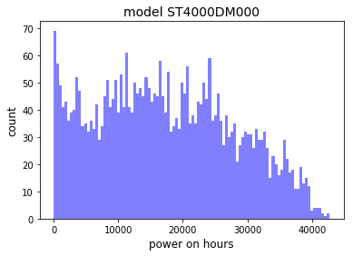

```python
n, bins, patches = plt.hist(df[df['model']=='ST4000DM000']['smart_9_raw'].dropna(how='any'), bins=100, facecolor='blue', alpha=0.5)
plt.xlabel('power on hours',fontsize=12)
plt.ylabel('count',fontsize=12);
plt.title('model ST4000DM000',fontsize=14);
```

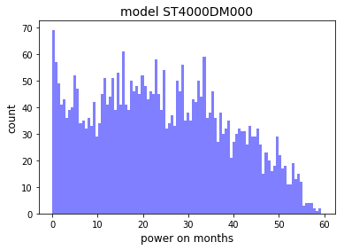

```python
n, bins, patches = plt.hist(df[df['model']=='ST4000DM000']['smart_9_raw'].dropna(how='any')/24/30, bins=100, facecolor='blue', alpha=0.5)
plt.xlabel('power on months',fontsize=12)
plt.ylabel('count',fontsize=12);
plt.title('model ST4000DM000',fontsize=14);
```